# Google Data Analytics Professional Certificate Capstone

Antonio Iannopollo

2025-06-02

## Business Task

Analyze FitBit Fitness Tracker Data to identify trends in smart device usage (activity, sleep, heart rate) and provide high-level recommendations for Bellabeat’s marketing strategy for the Leaf tracker, focusing on growth in the global smart device market.

## Data Sources

Source: FitBit Fitness Tracker Data (CC0, Kaggle, via Mobius), from 30 users, including daily activity, minute-level sleep, and second-level heart rate data.

Files Used:

- dailyActivity_merged_m1.csv, m2.csv: Steps, distance, calories.
- minuteSleep_merged_m1.csv, m2.csv: Sleep states (asleep, restless, awake).
- heartrate_seconds_merged_m1.csv, m2.csv: Heart rate.

Note: Original file names were modified by adding ’_m1’ or ’_m2’ to distinguish between files with identical names in the dataset.

Limitations: Small sample (30 users), no demographic data, outdated (2016), missing sleep (751 records) and heart rate (919 records) data.

## Data Cleaning and Processing

Activity: Merged dailyActivity_merged_m1.csv and m2.csv, standardized dates (mdy), no duplicates or missing values.

Sleep: Merged minuteSleep_merged_m1.csv and m2.csv, aggregated to daily totals (minutes asleep, restless, awake, time in bed, sleep records), no duplicates.

Heart Rate: Merged heartrate_seconds_merged_m1.csv and m2.csv, aggregated to daily averages, no duplicates.

Merged Data: Combined datasets by Id and Date using left_join.

```r
# Load and process data
daily_activity <- bind_rows(read_csv("dailyActivity_merged_m1.csv"), read_csv("dailyActivity_merged_m2.csv")) %>%
  mutate(ActivityDate = mdy(ActivityDate)) %>% rename(Date = ActivityDate)
sleep_combined <- bind_rows(read_csv("minuteSleep_merged_m1.csv"), read_csv("minuteSleep_merged_m2.csv")) %>%
  mutate(date = mdy_hms(date)) %>% mutate(Date = as.Date(date))
sleep_daily <- sleep_combined %>%
  group_by(Id, Date) %>%
  summarize(TotalMinutesAsleep = sum(value == 1, na.rm = TRUE),
            TotalMinutesRestless = sum(value == 2, na.rm = TRUE),
            TotalMinutesAwake = sum(value == 3, na.rm = TRUE),
            TotalTimeInBed = sum(value %in% c(1, 2, 3), na.rm = TRUE),
            SleepRecords = n_distinct(logId)) %>%
  ungroup()
heartrate_combined <- bind_rows(read_csv("heartrate_seconds_merged_m1.csv"), read_csv("heartrate_seconds_merged_m2.csv")) %>%
  mutate(Time = mdy_hms(Time)) %>% mutate(Date = as.Date(Time))
heartrate_daily <- heartrate_combined %>%
  group_by(Id, Date) %>%
  summarize(AvgHeartRate = mean(Value, na.rm = TRUE)) %>%
  ungroup()
combined_data <- daily_activity %>%
  left_join(heartrate_daily, by = c("Id", "Date")) %>%
  left_join(sleep_daily, by = c("Id", "Date"))
```

## Analysis Summary

Sleep: Weak negative correlation between sleep and steps (r = -0.17, p = 1.591e-05, 646 records), suggesting sleep tracking is used for rest/recovery.

Heart Rate: Weak positive correlation between heart rate and steps (r = 0.23, p = 3.812e-07, 478 records), indicating niche use.

Usage Patterns: All users track activity (100% of records), but only 46% track sleep and 34% track heart rate, reflecting inconsistent usage.

```r
## Summary statistics
activity_summary <- daily_activity %>%
  summarize(AvgSteps = mean(TotalSteps, na.rm = TRUE), AvgCalories = mean(Calories, na.rm = TRUE))
sleep_summary <- sleep_daily %>%
  summarize(AvgSleepMinutes = mean(TotalMinutesAsleep, na.rm = TRUE), AvgTimeInBed = mean(TotalTimeInBed, na.rm = TRUE))
heartrate_summary <- heartrate_daily %>%
  summarize(AvgHeartRate = mean(AvgHeartRate, na.rm = TRUE))
usage_summary <- combined_data %>%
  summarize(Users_Activity = n_distinct(Id[!is.na(TotalSteps)]), Users_Sleep = n_distinct(Id[!is.na(TotalMinutesAsleep)]),
            Users_HeartRate = n_distinct(Id[!is.na(AvgHeartRate)]))
print(activity_summary)
print(sleep_summary)
print(heartrate_summary)
print(usage_summary)
```

[output not shown]

## Visualizations

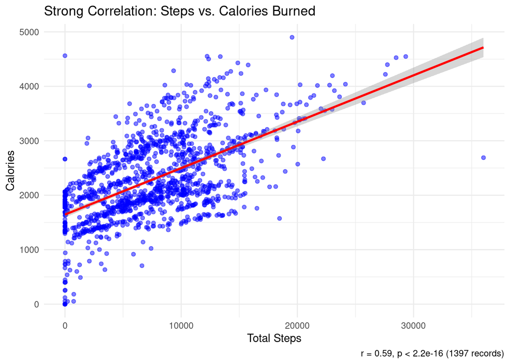

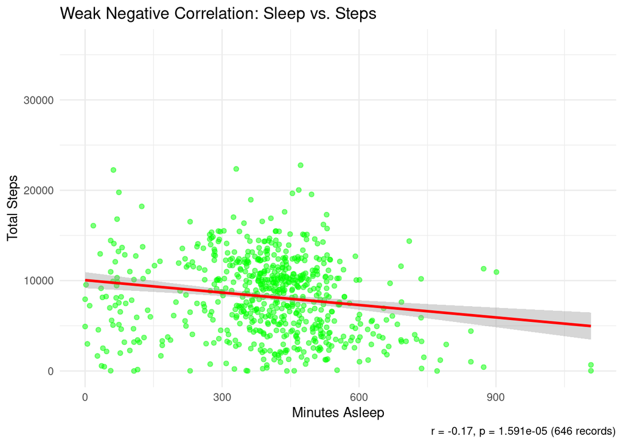

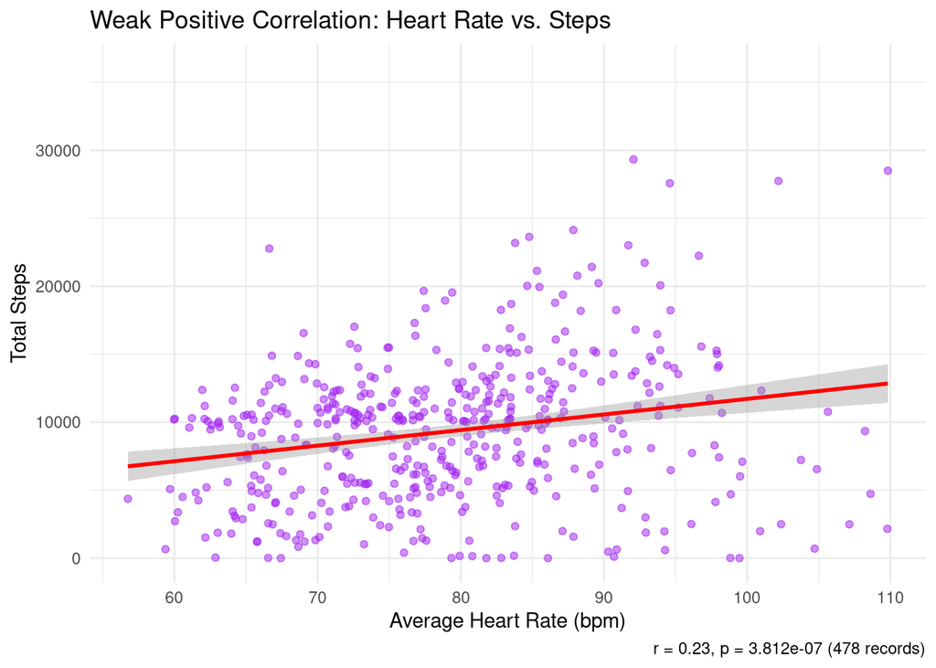

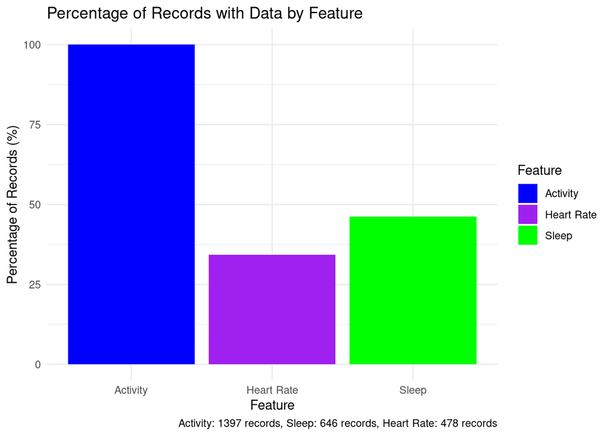

## Recommendations for Bellabeat

Emphasize Activity Tracking: Market Leaf as a stylish fitness tracker: “Track steps and calories with Leaf’s elegant design.” Use Instagram/YouTube ads.

Promote Sleep Tracking with Education: Highlight sleep insights and encourage nighttime wear: “Discover better rest with Leaf.”

Target Heart Rate as Premium Feature: Position heart rate for fitness/stress monitoring: “Monitor your heart rate with Leaf.”

Address Usage Barriers: Promote Leaf’s versatility (bracelet, necklace, clip) and app prompts to increase sleep/heart rate tracking.

Leverage Digital Marketing: Run video ads on Google, Instagram, YouTube for key dates (e.g., New Year’s).

Collect Proprietary Data: Gather female-specific data to validate trends for Bellabeat’s audience.